# Stats 230 Final Project 1 additional info

Zachary Serby

```r
## Load necessary packages
library(dplyr)
library(readxl)
library(stringr)
library(tidyverse)
library(rpart)
library(dplyr)
library(tidytext)
```

```r
library(ggplot2)
## Uploading necessary packages
library(nnet)
library(pROC)
library(caret)
library(rpart)
library(rpart.plot)
library(randomForest)
## Set working directory
setwd("C:\\Users\\zakse\\OneDrive\\Documents\\NEISS_87670\\NEISS_87670")

## List all files with the pattern ".XLSX"
file_list <- list.files(pattern = ".XLSX")

## Initialize an empty list to store data frames
dataframe_list <- list()

## Loop through each file and read data
for (file_name in file_list) {
  # Read data from Excel file
  data <- read_excel(file_name)

  ## Extract year from file_name and convert to integer
  Year <- as.integer(sub("^NEISS_(\\d{4})\\.XLSX", "\\1", file_name))

  ## Add year column to the data
  data$year <- Year

  ## Append the data frame to the list
  dataframe_list <- append(dataframe_list, list(data))
}

## Combine all data frames into a single data frame
combine_data <- bind_rows(dataframe_list)
cleaner_data <- combine_data[ -c(6, 7, 10:13, 15:21, 23:25) ] %>%
    filter(!Sex %in% c(0, 3))

cleaner_data$Disposition<- as.factor(cleaner_data$Disposition)
cleaner_data$Race<- as.factor(cleaner_data$Race)
cleaner_data$Sex<- as.factor(cleaner_data$Sex)

## Change the reference level of the categorical variable to "1 = White"
cleaner_data$Race <- relevel(cleaner_data$Race, ref = "1")
```

```r
##Cleaning and reorganizing the key, Assuming your key is stored in a file named "NEISS_FMT.XLSX" on your desktop
key_file <- "C:\\Users\\zakse\\OneDrive\\Desktop\\NEISS_FMT.XLSX"
## Read the key into a data frame
key_data <- read_excel(key_file)
## Rename column names
colnames(key_data) = c("format_name", "start_value", "end_value", "format_value")
## Remove all PROD variables
new_key <- key_data %>%
  filter(!format_name %in% c("PROD", "LOC", "HISP", "FIRE"))
```

### Conduct a Chi Square Test to check if the results are sufficient to suggest that all races and genders have an equal treatment chance.

Null Hypothesis: The probability of getting any treatment regardless sex is the same. H0:P(Treatment∣Sex)=P(Treatment)

```r
## Chi-squared test of association
chisq.test(x = table(cleaner_data$Disposition, cleaner_data$Sex))
```

```
##
##  Pearson's Chi-squared test
##
## data:  table(cleaner_data$Disposition, cleaner_data$Sex)
## X-squared = 127.54, df = 5, p-value < 2.2e-16
```

```r
## Fisher's Exact Test, looking at the variables Race and Disposition
fisher.test(x = table(cleaner_data$Disposition, cleaner_data$Race), simulate.p.value=TRUE)
```

```
##
##  Fisher's Exact Test for Count Data with simulated p-value (based on
##  2000 replicates)
##
## data:  table(cleaner_data$Disposition, cleaner_data$Race)
## p-value = 0.0004998
## alternative hypothesis: two.sided
```

The p-value of 2.2e-16 and 0.0004998 is much smaller than the common significance level of 0.05. Therefore, there is sufficient evidence to reject both null hypotheses, the probability of getting any disposition (treatment) regardless of sex and gender is the same. Based on the Chi-squared test, there does appear to be enough statistical evidence to further investigate the association between the variables Race|Sex and treatment.

### Checking accuracy of Multinomial Logistic Regression, Decision tree, and Random Forest

```r
## Fit a multinomial logistic regression model to cleaner_data
mfit <- multinom(Disposition ~ Race + Sex, data = cleaner_data)
```

```r
## Fit a decision tree
my_tree <- rpart(Disposition ~ Race + Sex, data = cleaner_data)

## Fit a random forest
rf <- randomForest(Disposition ~ Race + Sex, data = cleaner_data, ntree = 300)

## Function to calculate accuracy
calculate_accuracy <- function(model, data) {
  ## Get the predicted class probabilities
  fitted_probs <- predict(model, newdata = data, type = "prob")

  ## Find the index of the maximum probability for each observation
  most_likely <- apply(fitted_probs, 1, which.max)

  ## Map the indices to category labels
  pred_cats <- levels(data$Disposition)[most_likely]

  ## Calculate the fraction of correct predictions (accuracy)
  accuracy <- sum(pred_cats == data$Disposition) / nrow(data)

  return(accuracy)
}

## Calculate accuracy for each model
accuracy_mfit <- calculate_accuracy(mfit, cleaner_data)
accuracy_tree <- calculate_accuracy(my_tree, cleaner_data)
accuracy_rf <- calculate_accuracy(rf, cleaner_data)

## Print the accuracies
cat("Multinomial Logistic Regression Accuracy:", accuracy_mfit, "\n")
```

```
## Multinomial Logistic Regression Accuracy: 0.9022879
```

```r
cat("Decision Tree Accuracy:", accuracy_tree, "\n")
```

```
## Decision Tree Accuracy: 0.9022879
```

```r
cat("Random Forest Accuracy:", accuracy_rf, "\n")
```

```
## Random Forest Accuracy: 0.9022879
```

Multinomial logistic regression did not outperform classification trees on this dataset. The reason for this is because there was no over-fitting because no splits occurred in the decision tree. It appears that all models have the exact same accuracy level of 0.9022879.

### Because of identical accuracy results, we are inclined to further investigate the efficacy of a model by looking at the AUC for each model.

### AUC Graph and calculations for Multinomial Logistic Regression

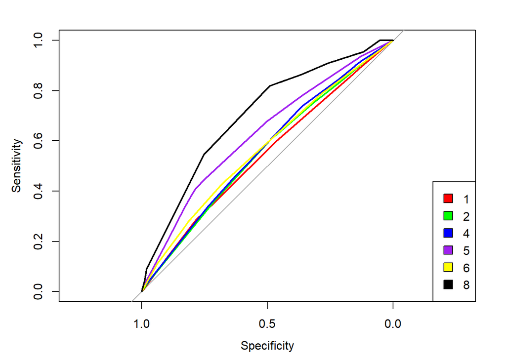

```r
## Get predicted probabilities for each class (class in this case are the different dispositions) for the multinomial logistic regression model
predicted_probs <- predict(mfit, newdata = cleaner_data, "probs")

## Extract the true class labels
true_labels <- cleaner_data$Disposition

## Create a ROC curve for each class, needed to do research on code from various sites online: Stack overflow, Rdocumentation, Cross Validated
roc_multiclass <- lapply(1:nlevels(true_labels), function(i) {
  roc(as.numeric(true_labels == levels(true_labels)[i]), predicted_probs[, i])
}) ## apply function to each class using lapply, use function(i) to calculate ROC curve for the class represented by this index, use predicted probabilities for the currrent class
## Plot the multiclass ROC curves
colors <- c("red", "green", "blue", "purple", "yellow", "black")  # Adjust colors as needed
for (i in 1:length(roc_multiclass)) {
  plot(roc_multiclass[[i]], col = colors[i], add = i > 1)
} ## "roc_multiclass[[i]]" plots ROC curve for the current class, col = colors[i] specifies color

## Add a Legend to the bottom
legend("bottomright", legend = levels(true_labels), fill = colors)
```

```r
## Calculate AUC for each class, roc_multiclass is a list of ROC curves, use sapply to apply the function to each element of the list, "roc_class" represents the ROC curve for a specific class
auc_values <- sapply(roc_multiclass, function(roc_class) {
  auc(roc_class)
})
## Print AUC values
print(auc_values)
```

```
## [1] 0.5442245 0.5542211 0.5630945 0.6269718 0.5699841 0.6992895
```

### AUC Graph and calculations for Decision Tree

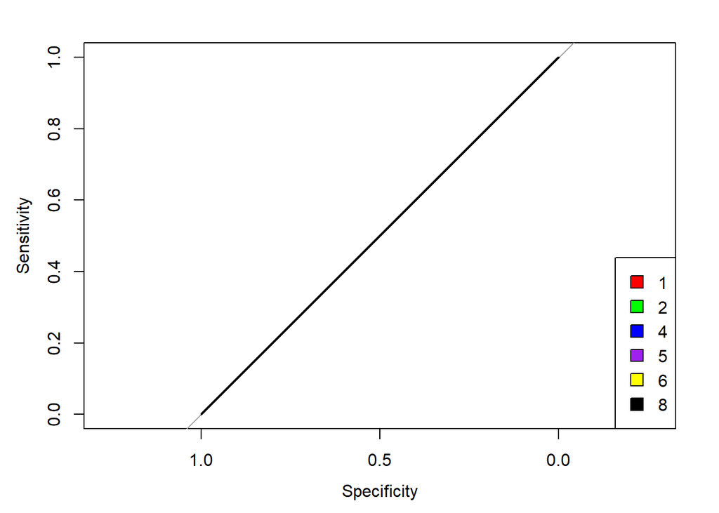

```r
## Get predicted probabilities for each class (class in this case are the different dispositions) for the decision tree model
predicted_probs <- predict(my_tree, newdata = cleaner_data, "prob")

## Extract the true class labels
true_labels <- cleaner_data$Disposition

## Create a ROC curve for each class, needed to do research on code from various sites online: Stack overflow, Rdocumentation, Cross Validated
roc_multiclass <- lapply(1:nlevels(true_labels), function(i) {
  roc(as.numeric(true_labels == levels(true_labels)[i]), predicted_probs[, i])
}) ## apply function to each class using lapply, use function(i) to calculate ROC curve for the class represented by this index, use predicted probabilities for the currrent class
## Plot the multiclass ROC curves
colors <- c("red", "green", "blue", "purple", "yellow", "black")  # Adjust colors as needed
for (i in 1:length(roc_multiclass)) {
  plot(roc_multiclass[[i]], col = colors[i], add = i > 1)
} ## "roc_multiclass[[i]]" plots ROC curve for the current class, col = colors[i] specifies color

## Add Legend to the bottom
legend("bottomright", legend = levels(true_labels), fill = colors)
```

```r
## Calculate AUC for each class, roc_multiclass is a list of ROC curves, use sapply to apply the function to each element of the list, "roc_class" represents the ROC curve for a specific class
auc_values <- sapply(roc_multiclass, function(roc_class) {
  auc(roc_class)
})
## Print AUC values
print(auc_values)
```

```
## [1] 0.5 0.5 0.5 0.5 0.5 0.5
```

We are assessing the overall AUC values of the ROC curves within each model in comparison to one another. This model appears to have the same AUC values of 0.5 for all classes of dispositions. These AUC values are lower than our multinomial logistic regression model. An AUC of 1 indicates perfect classification, while an AUC of 0.5 is akin to random guessing.

### AUC Graph and calculations for Random Forest

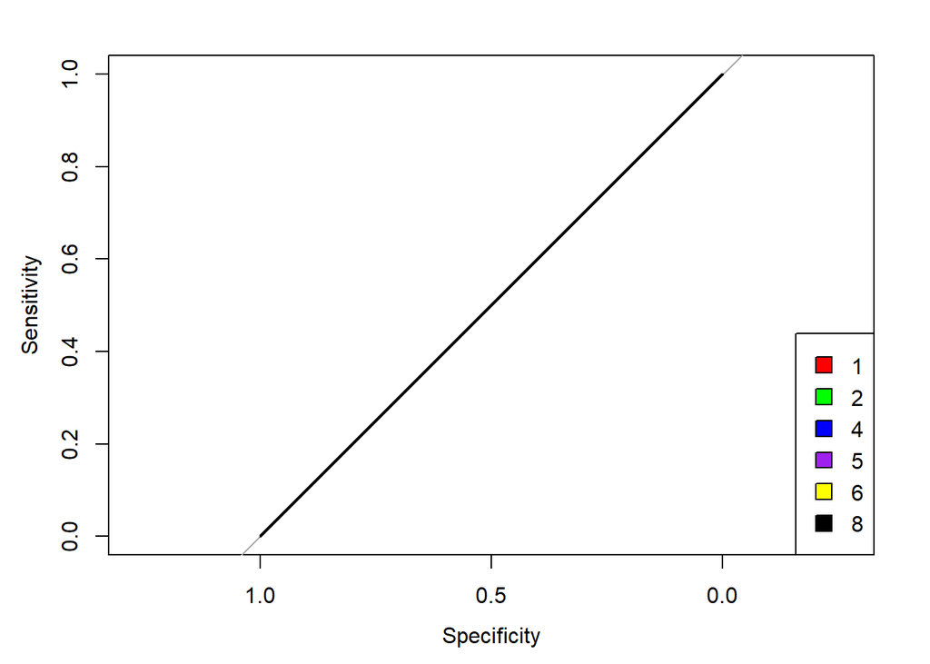

```r
## Get predicted probabilities for each class (class in this case are the different dispositions) for the random forest model
predicted_probs <- predict(rf, newdata = cleaner_data, "prob")

## Extract the true class labels
true_labels <- cleaner_data$Disposition

## Create a ROC curve for each class, needed to do research on code from various sites online: Stack overflow, Rdocumentation, Cross Validated
roc_multiclass <- lapply(1:nlevels(true_labels), function(i) {
  roc(as.numeric(true_labels == levels(true_labels)[i]), predicted_probs[, i])
}) ## apply function to each class using lapply, use function(i) to calculate ROC curve for the class represented by this index, use predicted probabilities for the currrent class
## Plot the multiclass ROC curves
colors <- c("red", "green", "blue", "purple", "yellow", "black")  # Adjust colors as needed
for (i in 1:length(roc_multiclass)) {
  plot(roc_multiclass[[i]], col = colors[i], add = i > 1)
} ## "roc_multiclass[[i]]" plots ROC curve for the current class, col = colors[i] specifies color

## Add Legend a legend to the bottom
legend("bottomright", legend = levels(true_labels), fill = colors)
```

```r
## Calculate AUC for each class, roc_multiclass is a list of ROC curves, use sapply to apply the function to each element of the list, "roc_class" represents the ROC curve for a specific class
auc_values <- sapply(roc_multiclass, function(roc_class) {
  auc(roc_class)
})

## Print AUC values
print(auc_values)
```

```
## [1] 0.5 0.5 0.5 0.5 0.5 0.5
```

We are assessing the overall AUC values of the ROC curves within each model in comparison to one another. The random forest model appears to have the same AUC values of 0.5 for all classes of dispositions, similar to the decision tree. These AUC values are also lower than our multinomial logistic regression model. An AUC of 1 indicates perfect classification, while an AUC of 0.5 is akin to random guessing.Therefore we can proceed in justifying our multinomial logistic regression model will represent our data the best for this project.

### Multinomial Logistic Regression

```r
## Looking at summary of the data
summary(cleaner_data)
```

```
##  CPSC_Case_Number    Treatment_Date                        Age        Sex
##  Min.   :130108537   Min.   :2013-01-01 00:00:00.00   Min.   :16.00   1:28583
##  1st Qu.:150726022   1st Qu.:2015-06-28 00:00:00.00   1st Qu.:19.00   2:15956
##  Median :180222744   Median :2018-02-01 00:00:00.00   Median :22.00
##  Mean   :176618866   Mean   :2018-01-18 03:11:45.39   Mean   :22.49
##  3rd Qu.:200855612   3rd Qu.:2020-08-19 00:00:00.00   3rd Qu.:26.00
##  Max.   :230303092   Max.   :2022-12-31 00:00:00.00   Max.   :30.00
##
##  Race        Body_Part       Diagnosis     Disposition  Narrative
##  1:18058   Min.   : 0.00   Min.   :41.00   1:40187     Length:44539
##  0:15758   1st Qu.:33.00   1st Qu.:51.00   2:  714     Class :character
##  2: 7446   Median :79.00   Median :55.00   4: 2553     Mode  :character
##  3: 2134   Mean   :64.09   Mean   :57.28   5:  273
##  4:  878   3rd Qu.:85.00   3rd Qu.:61.00   6:  790
##  5:  180   Max.   :94.00   Max.   :74.00   8:   22
##  6:   85
##       year
##  Min.   :2013
##  1st Qu.:2015
##  Median :2018
##  Mean   :2018
##  3rd Qu.:2020
##  Max.   :2022
##
```

```r
## Fit a multinomial logistic regression model to cleaner_data
mfit <- multinom(Disposition ~ Race + Sex, data = cleaner_data)
## Look at coefficients of mfit
coef(mfit)
```

```
##   (Intercept)      Race0       Race2         Race3       Race4       Race5
## 2   -3.833905 -0.1065435 -0.31497024    0.03900372 -0.55690102  -1.0716289
## 4   -2.549320 -0.1628357 -0.02477197   -0.13163551 -0.14760114   0.7825673
## 5   -5.096859 -0.3493709  0.81202829    0.67645179  0.24815239   1.5171628
## 6   -4.214509  0.1762796  0.62043931    0.36903390  0.02255313  -0.1911662
## 8   -7.502091  0.5771258 -0.33768405 -184.73033711  1.74787334 -15.6603861
##         Race6       Sex2
## 2  -0.3374062 -0.3095791
## 4   0.7194909 -0.4626287
## 5 -15.6988487 -0.1350744
## 6   0.9829705  0.1914944
## 8  -7.7479393 -0.9383597
```

```r
## Interpret the effects of these coefficients after exponentiation
## Take the exponent of the coefficients for "Race + Sex"
exp(coef(mfit)[,2:8])
```

```
##       Race0     Race2        Race3     Race4        Race5        Race6
## 2 0.8989359 0.7298106 1.039774e+00 0.5729820 3.424502e-01 7.136189e-01
## 4 0.8497307 0.9755323 8.766605e-01 0.8627752 2.187080e+00 2.053388e+00
## 5 0.7051316 2.2524720 1.966886e+00 1.2816552 4.559271e+00 1.520816e-07
## 6 1.1927716 1.8597449 1.446337e+00 1.0228094 8.259953e-01 2.672383e+00
## 8 1.7809124 0.7134207 5.924258e-81 5.7423776 1.580450e-07 4.316311e-04
##        Sex2
## 2 0.7337557
## 4 0.6296264
## 5 0.8736510
## 6 1.2110580
## 8 0.3912691
```

** Note that there are 8 treatments in the key but the treatment no injury (treatment = 0) and treatment unknown (treatment = 9) have zero patients.

There’s a decrease in the likelihood of being treated and transferred (treatment 2) when you are black (Race 2) relative to white (Race 1 our reference level). And there’s a decrease in likelihood of being treated and transferred (treatment 2) if you are a woman relative to a man.

### Multinomial Logistic Regression

```r
library(broom)
## Fit a multinomial logistic regression model to cleaner_data
mfit <- multinom(Disposition ~ Race + Sex, data = cleaner_data)
## Convert model coefficients to a tidy data frame
tidy_mfit <- tidy(mfit)
```

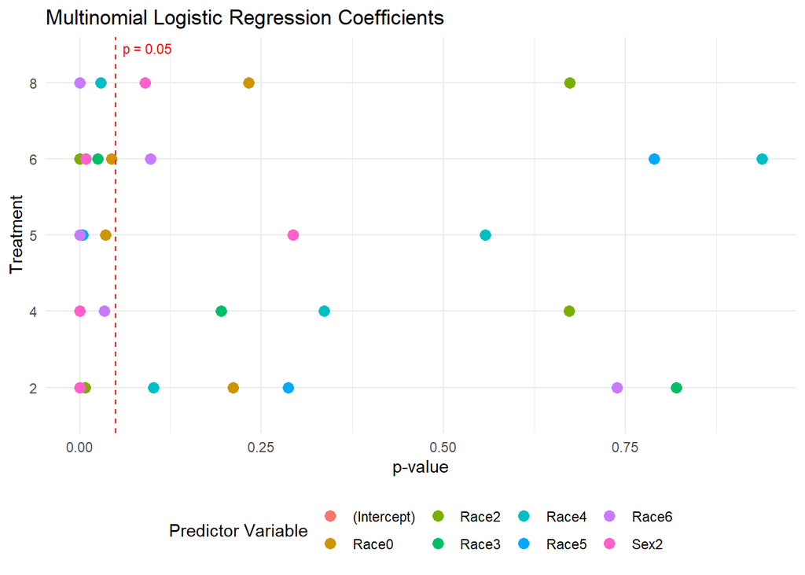

```r
## Create a coefficient plot with p-value on the x-axis, Disposition levels on the y-axis, and color based on the predictor variable (term)
ggplot(tidy_mfit, aes(x = p.value, y = factor(y.level), color = term)) +
  geom_point(size = 3) +
  geom_vline(xintercept = 0.05, linetype = "dashed", color = "red") +  ## Add vertical line at p-value 0.05
  annotate("text", x = 0.06, y = Inf, vjust = 1.5, label = "p = 0.05", color = "red", size = 3, hjust = 0) +  ## Label the line at p-value 0.05
  labs(title = "Multinomial Logistic Regression Coefficients",
       x = "p-value",
       y = "Treatment",
       color = "Predictor Variable") +
  theme_minimal() +
  theme(legend.position = "bottom")  ## Add legend position to bottom
```

The purple marker at treatment 8 represents a a significant p-value lower than 0.05 therefore we reject the null hypothesis that NATIVE HAWAIIAN/PACIFIC ISLANDER relative to white people are equally likely to have died in the Emergency Room. We have sufficient evidence to suggest that we should look into the disparities between NATIVE HAWAIIAN/PACIFIC ISLANDER and white people who have died in the ER for this point.

### Decision tree

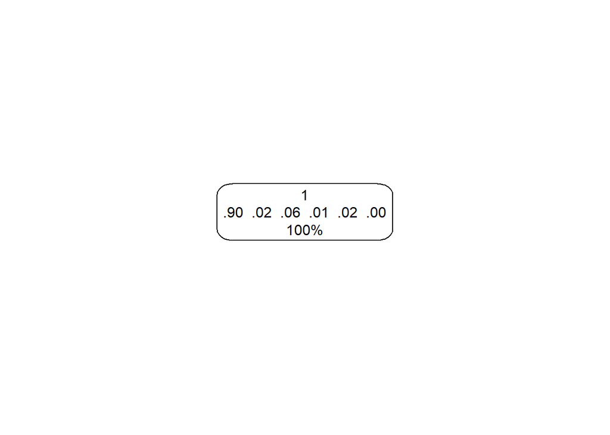

```r
## Fit decision tree to data set, keep in mind no adjustments of cp and minsplit change the decision tree
my_tree <- rpart(Disposition ~ Race + Sex, data = cleaner_data)
prp(my_tree, extra=104) ## "extra = 104" adds some info to the tree
```

** Note that there are 8 treatments in the key but the treatment no injury (treatment = 0) and treatment unknown (treatment = 9) have zero patients.

The first line in this node tells us that the most common class in this node is TREATED/EXAMINED AND RELEASED (Treatment = 1). The next line indicates that 90% of patients have been treated/examined and released (received treatment 1), 2% have been treated and transferred (treatment 2), 6% have been treated and admitted to the hospital (treatment 4), 1% have been treated and held for observation (treatment 5), 2% have left without being seen (treatment 6), and 0% have died in the ER. This decision tree model rounds to the nearest hundredth decimal place.

### Random Forests

```r
## Fit random forest model to the data set, using B=300
rf <- randomForest(Disposition ~ Race + Sex, data = cleaner_data, ntree = 300)
rf$importance ## Look at variable importance
```

```
##      MeanDecreaseGini
## Race         5.324166
## Sex         11.805012
```

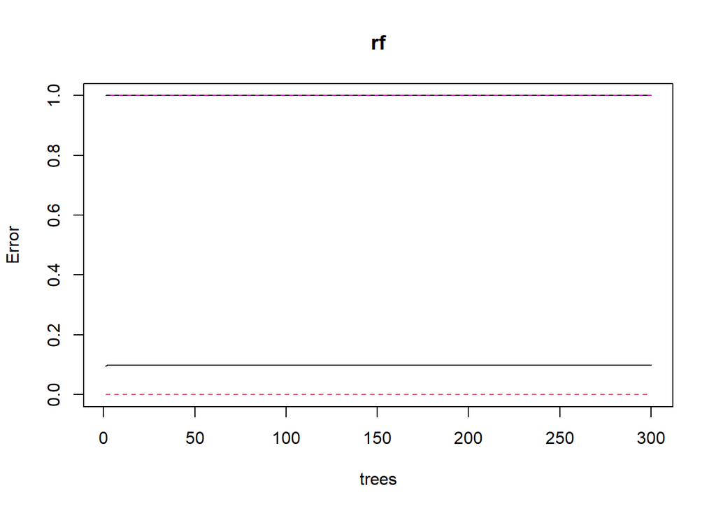

```r
plot(rf) ## Plot random forest
```

The error rate isn’t improving because it’s always predicting the dominant category treatment (Treatment 1 = Treated and Released) as more decision trees are added to the model. Although the forest tree is dominated by treatment one can still see an improvement in the gini gain.

### Additional Info and Visualizations

### Looking at the most common words for each gender and sex

Looking at the most common words for each race and sex within Narrative column you can see that the terminology that patients use depending on race and gender are different. Terminology could be a factor in why there’s a disparity in dispositions among genders/races.

```r
## Look at most common words for male and females within Narrative column
## Create new dataframe for sex and narrative
narrative_sex_data <- cleaner_data %>%
  select(Narrative, Sex)

## Split narrative into individual words
words <- str_split(narrative_sex_data$Narrative, "\\s+")

## Put into a tidy format
tidy_form <- tibble(word = unlist(words), ## Extract individual words from narrative by converting list of words to a vector
                    row = rep(1:length(words), lengths(words)), ## Assign each word to the narrative it belongs to
                    Sex = rep(narrative_sex_data$Sex, lengths(words)) ## Pair the Sex information to each word/narrative pair
                    )

## Filter words with four letters or longer
tidy_form_filtered <- tidy_form %>%
  filter(str_length(word) >= 4)

## Count the frequency of each word, grouped by Sex
freq_word <- tidy_form_filtered %>%
  group_by(Sex, word) %>%
  count(sort = TRUE)

## View the most common words for each Sex group
pop_words_sex <- freq_word %>%
  group_by(Sex) %>%
  slice_max(n = 10, order_by = n)

## Print the result
print(pop_words_sex)
```

```
## # A tibble: 20 × 3
## # Groups:   Sex [2]
##    Sex   word            n
##    <fct> <chr>       <int>
##  1 1     SHOULDER     9326
##  2 1     DISLOCATION  7030
##  3 1     FINGER       6172
##  4 1     PLAYING      5959
##  5 1     WITH         5197
##  6 1     WHEN         4408
##  7 1     FELL         4239
##  8 1     BURN         4094
##  9 1     WHILE        3942
## 10 1     LEFT         3684
## 11 2     BURN         4161
## 12 2     WITH         3022
## 13 2     FINGER       2470
## 14 2     HAND         2363
## 15 2     WHEN         2281
## 16 2     FELL         2190
## 17 2     LEFT         1952
## 18 2     PAIN         1849
## 19 2     SHOULDER     1826
## 20 2     DISLOCATION  1786
```

```r
## Look at most common words for each race within Narrative column
## Create new dataframe for race and narrative
narrative_race_data <- cleaner_data %>%
  select(Narrative, Race)

## Split narrative into individual words
words <- str_split(narrative_race_data$Narrative, "\\s+")

## Put into a tidy format
tidy_form <- tibble(word = unlist(words), ## Extract individual words from narrative by converting list of words to a vector
                    row = rep(1:length(words), lengths(words)), ## Assign each word to the narrative it belongs to
                    Race = rep(narrative_race_data$Race, lengths(words)) ## Pair the Sex information to each word/narrative pair
                    )

## Filter words with four letters or longer
tidy_form_filtered <- tidy_form %>%
  filter(str_length(word) >= 4)

## Count the frequency of each word, grouped by Race
freq_word <- tidy_form_filtered %>%
  group_by(Race, word) %>%
  count(sort = TRUE)

## View the most common words for each Race group
pop_words_race <- freq_word %>%
  group_by(Race) %>%
  slice_max(n = 10, order_by = n)

## Print the result
print(pop_words_race)
```

```
## # A tibble: 71 × 3
## # Groups:   Race [7]
##    Race  word            n
##    <fct> <chr>       <int>
##  1 1     SHOULDER     4698
##  2 1     WITH         3613
##  3 1     DISLOCATION  3608
##  4 1     BURN         3558
##  5 1     FINGER       3411
##  6 1     WHEN         2892
##  7 1     FELL         2841
##  8 1     HAND         2752
##  9 1     LEFT         2732
## 10 1     PAIN         2446
## # ℹ 61 more rows
```

### Visualization of Gender proportion and Race Proportion

Visualization of Gender proportion and Race Proportion in each Disposition/Treatment, to get a general undestanding of the data distribution

```r
## This is for the segmented bar graph
segment_bar_data <- cleaner_data %>%
  select(Disposition, Sex, Race) %>%
  mutate(
    Disposition = case_when(
    Disposition == 1 ~ "TRE/REL",
    Disposition == 2 ~ "TRE/TRANS",
    Disposition == 4 ~ "TRE/HOSP",
    Disposition == 5 ~ "HELD",
    Disposition == 6 ~ "NOTSEEN",
    Disposition == 8 ~ "DIED",
    Disposition == 9 ~ "UNKNOWN"
    ))
```

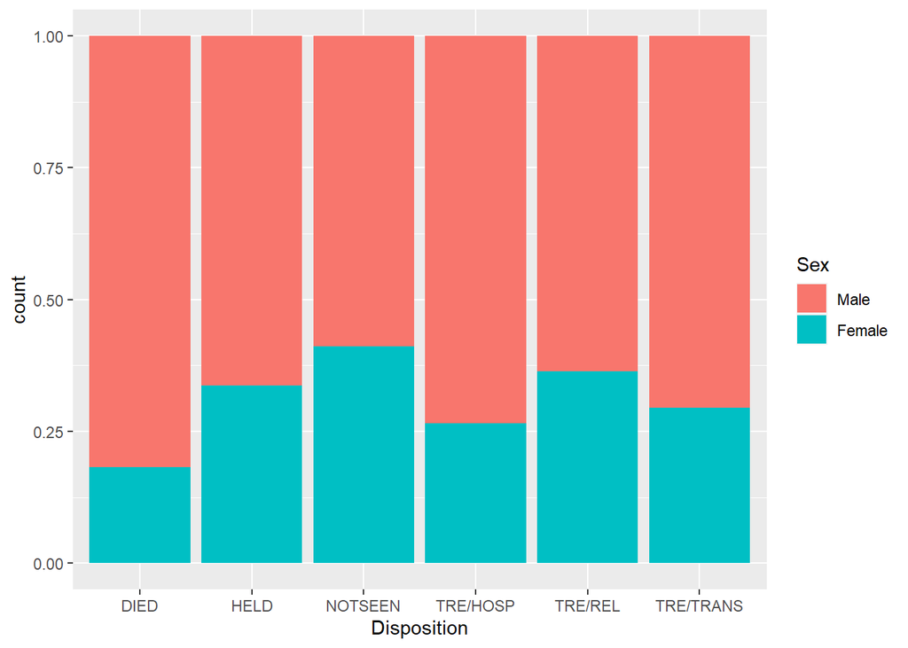

```r
## Create a segmented bar chart colored by sex
ggplot(segment_bar_data, aes(x = Disposition, fill = Sex)) +
  geom_bar(position = "fill") +
  scale_fill_discrete(labels = c("Male", "Female"))
```

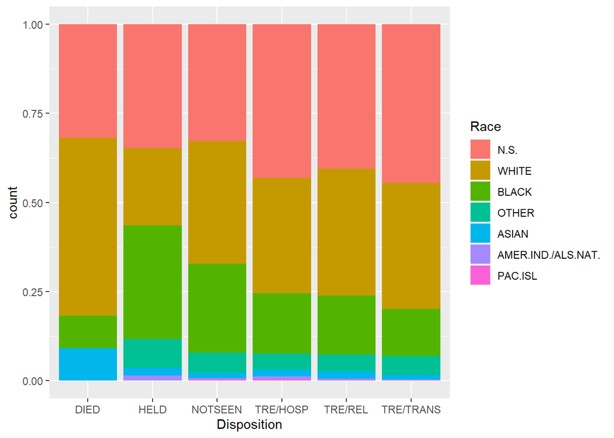

```r
## Create a segmented bar chart colored by Race
ggplot(segment_bar_data, aes(x = Disposition, fill = Race)) +
  geom_bar(position = "fill") +
  scale_fill_discrete(labels = c("N.S.", "WHITE", "BLACK", "OTHER", "ASIAN", "AMER.IND./ALS.NAT.", "PAC.ISL"))
```

### Analyzing multinomial logistic regression and results ommitting Treatment 1 from the dataset.

Treatment 1 is found to be a majority of the dataset, therefore we want to see if our predictor variables are statistically signficant without the influence of Treatment 1.

```r
## Create a dataframe ommitting Treatment 1
Removed_treatment1 <- cleaner_data %>%
  filter(Disposition != 1)
## Change the reference level of the categorical variable to "1 = White"
Removed_treatment1$Race <- relevel(Removed_treatment1$Race, ref = "1")
```

```r
library(broom)

## Fit a multinomial logistic regression model to Removed_Treatment1 dataset
mfit <- multinom(Disposition ~ Race + Sex, data = Removed_treatment1)
```

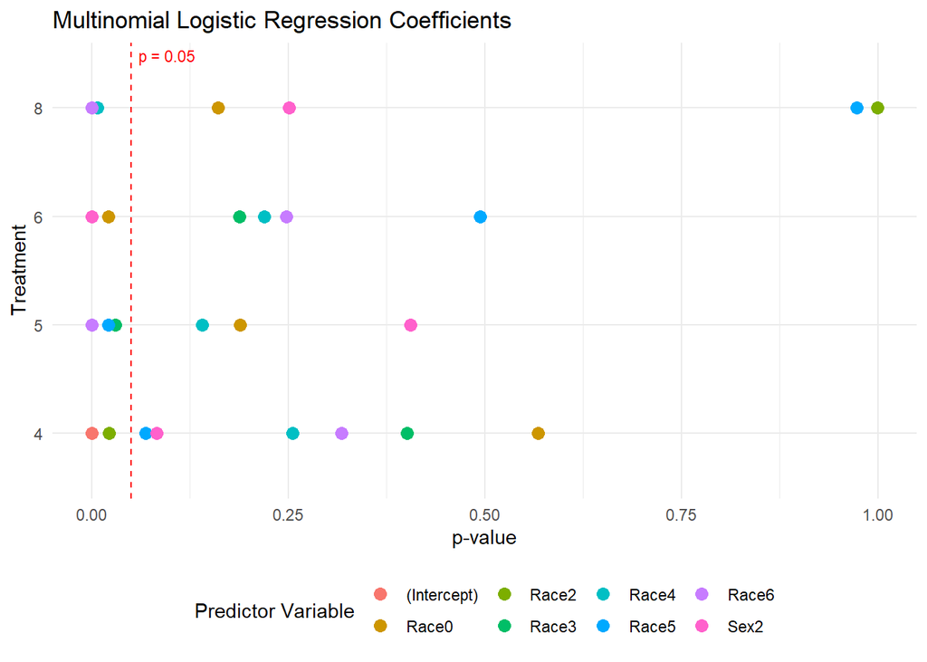

```r
## Convert model coefficients to a tidy data frame
tidy_mfit <- tidy(mfit)

## Create a coefficient plot with p-value on the x-axis, Disposition levels on the y-axis, and color based on the predictor variable (term)
ggplot(tidy_mfit, aes(x = p.value, y = factor(y.level), color = term)) +
  geom_point(size = 3) +
  geom_vline(xintercept = 0.05, linetype = "dashed", color = "red") +  ## Add vertical line at p-value 0.05
  annotate("text", x = 0.06, y = Inf, vjust = 1.5, label = "p = 0.05", color = "red", size = 3, hjust = 0) +  ## Label the line at p-value 0.05
  labs(title = "Multinomial Logistic Regression Coefficients",
       x = "p-value",
       y = "Treatment",
       color = "Predictor Variable") +
  theme_minimal() +
  theme(legend.position = "bottom")  ## Add legend position to bottom
```